# R Notebook

```r
library(dplyr)
```

[output not shown]

```r
library(ggplot2)
library(FactoMineR)
library(factoextra)
```

## QUESTION 1

```r
data <- read.csv("ScrewCaps.csv")
data %>% names
```

```
 [1] "X"              "Supplier"       "Diameter"       "weight"         "nb.of.pieces"   "Shape"
 [7] "Impermeability" "Finishing"      "Mature.Volume"  "Raw.Material"   "Price"          "Length"
```

```r
data %>% summary
```

```
       X               Supplier      Diameter          weight       nb.of.pieces        Shape     Impermeability
 Min.   :  1.0   Supplier A: 31   Min.   :0.4458   Min.   :0.610   Min.   : 2.000   Shape 1:134   Type 1:172
 1st Qu.: 50.5   Supplier B:150   1st Qu.:0.7785   1st Qu.:1.083   1st Qu.: 3.000   Shape 2: 45   Type 2: 23
 Median : 99.0   Supplier C: 14   Median :1.0120   Median :1.400   Median : 4.000   Shape 3:  8
 Mean   : 98.9                    Mean   :1.2843   Mean   :1.701   Mean   : 4.113   Shape 4:  8
 3rd Qu.:147.5                    3rd Qu.:1.2886   3rd Qu.:1.704   3rd Qu.: 5.000
 Max.   :196.0                    Max.   :5.3950   Max.   :7.112   Max.   :10.000
        Finishing   Mature.Volume    Raw.Material     Price            Length
 Hot Printing: 62   Min.   :  1000   ABS: 21      Min.   : 6.477   Min.   : 3.369
 Lacquering  :133   1st Qu.: 15000   PP :148      1st Qu.:11.807   1st Qu.: 6.161
                    Median : 45000   PS : 26      Median :14.384   Median : 8.086
                    Mean   : 96930                Mean   :16.444   Mean   :10.247
                    3rd Qu.:115000                3rd Qu.:18.902   3rd Qu.:10.340
                    Max.   :800000                Max.   :46.610   Max.   :43.359
```

```r
data %>% View
```

Just uploading and observing the structure of the dataset

## QUESTION 2

### Price Study

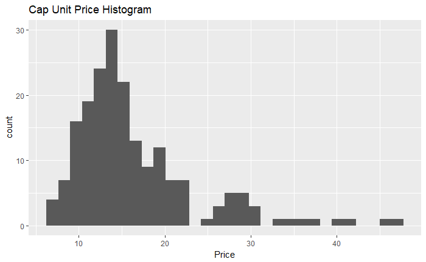

```r
ggplot(data, aes(x = Price)) + geom_histogram() + ggtitle("Cap Unit Price Histogram")
```

```r
summary(data$Price)
```

```
   Min. 1st Qu.  Median    Mean 3rd Qu.    Max.
  6.477  11.807  14.384  16.444  18.902  46.610
```

```r
quantile(data$Price, probs = seq(0,1,length = 11))
```

```
       0%       10%       20%       30%       40%       50%       60%       70%       80%       90%      100%
 6.477451  9.764729 11.430209 12.503225 13.552593 14.384413 15.678566 17.632191 20.012644 27.174983 46.610372
```

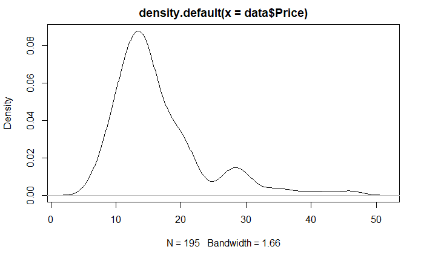

```r
density_price <- density(data$Price)
plot(density_price)
```

### Correlation between price and quantitative variables

```r
cor(data$Price,data$Length)
```

```
[1] 0.7997892
```

```r
cor(data$Price,data$weight)
```

```
[1] 0.787921
```

### Correlation between price and categorical variables

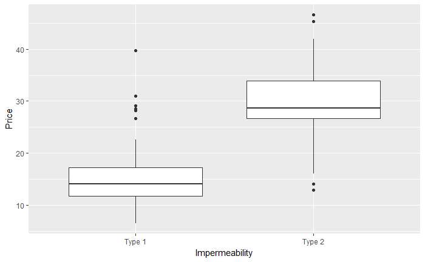

```r
ggplot(data, aes(x = Impermeability, y = Price)) + geom_boxplot()
```

```r
Impermeability_group <- data %>%
              group_by(Impermeability)
```

The correlation between the price and impermeability seems obvious considering the boxplot: the second impermeability type seems to induce higher prices which are way higher. If we do not consider the outliers the 1st quartile of the second impermeability type is higher than the 90% of the price of the type 1 impermeability caps.

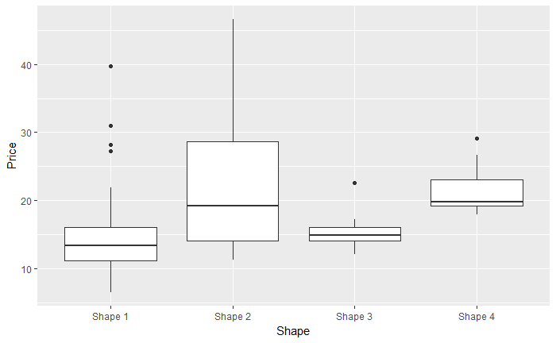

```r
ggplot(data, aes(x = Shape, y = Price)) + geom_boxplot()
```

```r
data %>%
  group_by(Shape) %>%
  summarize(mean(Price))
```

| Shape | mean(Price) |
| --- | --- |
| Shape 1 | 14.20058 |
| Shape 2 | 22.34091 |
| Shape 3 | 15.65162 |
| Shape 4 | 21.63988 |

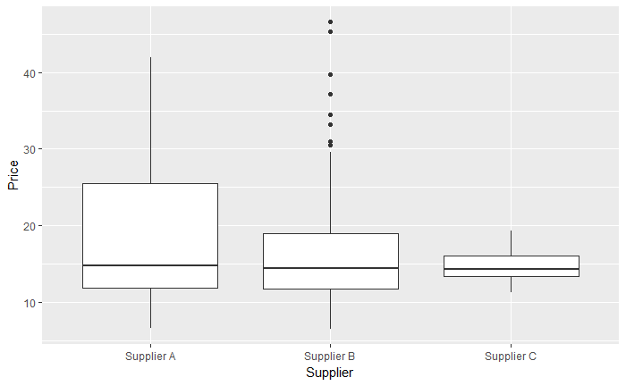

```r
ggplot(data, aes(x = Supplier, y = Price)) + geom_boxplot()
```

```r
data %>%
  group_by(Supplier) %>%
  summarize(mean(Price))
```

| Supplier | mean(Price) |
| --- | --- |
| Supplier A | 18.02897 |
| Supplier B | 16.26141 |
| Supplier C | 14.88869 |

The box plot show wide difference in variance between suppliers but no real price difference. If we consider the means, the 3rd supplier seems slightly cheaper but nothing is obvious. We may see later whether some categorical data can show true differences between suppliers which are hiddent by the different types of caps in this graph.

## QUESTION 3

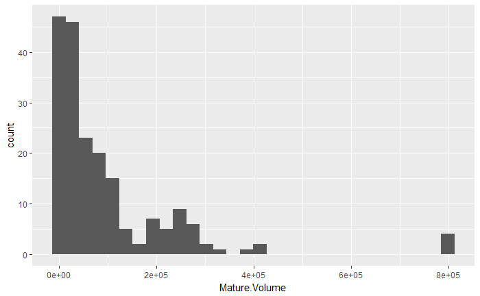

```r
print(ggplot(data, aes(x = Mature.Volume)) + geom_histogram())
```

```r
quantile(data$Mature.Volume, probs = seq(0,1,length = 11))
```

```
    0%    10%    20%    30%    40%    50%    60%    70%    80%    90%   100%
  1000   8000  12000  20000  30000  45000  69400  99000 152000 248000 800000
```

```r
outliers <- data %>% filter(Mature.Volume>=5e+05)
outliers %>% print
```

| X | Supplier | Diameter | weight | nb.of.pieces | Shape | Impermeability | Finishing | Mature.Volume | Raw.Material | Price | Length |
| --- | --- | --- | --- | --- | --- | --- | --- | --- | --- | --- | --- |
| 11 | Supplier A | 0.79 | 1.06 | 4 | Shape 1 | Type 1 | Lacquering | 800000 | PP | 12.256185 | 6.209053 |
| 14 | Supplier A | 0.79 | 1.06 | 4 | Shape 1 | Type 1 | Lacquering | 800000 | PP | 9.416743 | 6.412783 |
| 38 | Supplier B | 0.79 | 1.06 | 4 | Shape 1 | Type 1 | Lacquering | 800000 | PP | 11.113649 | 6.421937 |
| 51 | Supplier B | 0.79 | 1.06 | 4 | Shape 1 | Type 1 | Lacquering | 800000 | PP | 12.269223 | 6.212285 |

The plotting show that 4 values look completely abnormal with 8e+05 volumes (which is over 3 times the 9th decile of the Mature.VOlume varaible) These are suspicious as the volume are exactly the same (maybe a mistake in data reporting) and seem off compared to the rest of the information. After taking them off, we can try to plot the histogram another time to see if other values seem off.

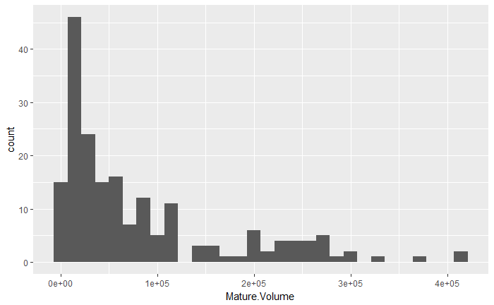

```r
data_clean <- data[!(data[,"X"] %in% outliers[,"X"]),]
ggplot(data_clean, aes(x = Mature.Volume)) + geom_histogram()
```

## QUESTION 4

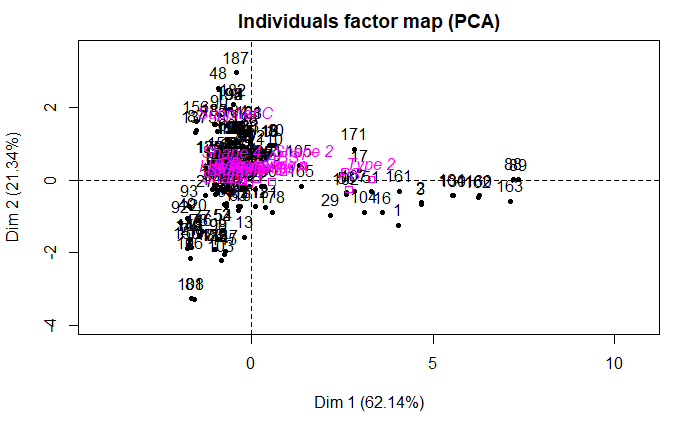

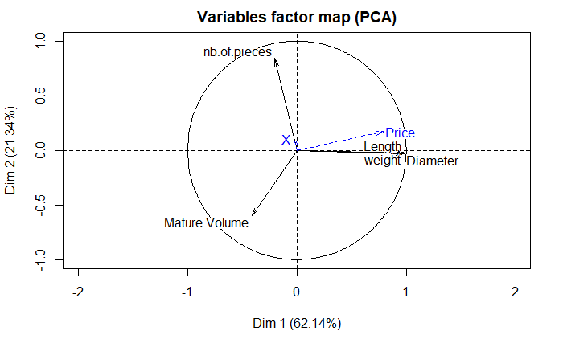

```r
res.pca <- PCA(data_clean, quanti.sup = c(1,11), quali.sup = c(2,6,7,8,10), scale = T)
```

```r
summary(res.pca, nbelements = 6, ncp = 4)
```

```
Call:
PCA(X = data_clean, scale.unit = T, quanti.sup = c(1, 11), quali.sup = c(2,
     6, 7, 8, 10))


Eigenvalues
                       Dim.1   Dim.2   Dim.3   Dim.4   Dim.5
Variance               3.107   1.067   0.777   0.049   0.000
% of var.             62.142  21.338  15.537   0.976   0.006
Cumulative % of var.  62.142  83.481  99.018  99.994 100.000

Individuals (the 6 first)
                  Dist    Dim.1    ctr   cos2    Dim.2    ctr   cos2    Dim.3    ctr   cos2    Dim.4    ctr   cos2
1             |  4.259 |  4.026  2.731  0.894 | -1.247  0.763  0.086 | -0.008  0.000  0.000 | -0.613  4.031  0.021 |
2             |  4.740 |  4.674  3.681  0.972 | -0.633  0.196  0.018 |  0.466  0.146  0.010 | -0.073  0.057  0.000 |
3             |  4.739 |  4.662  3.662  0.968 | -0.671  0.221  0.020 |  0.518  0.181  0.012 | -0.074  0.058  0.000 |
4             |  0.966 |  0.050  0.000  0.003 |  0.451  0.100  0.218 | -0.796  0.427  0.680 |  0.305  0.995  0.100 |
5             |  1.644 | -0.771  0.100  0.220 | -0.314  0.048  0.036 |  1.408  1.337  0.734 | -0.161  0.277  0.010 |
6             |  0.802 | -0.507  0.043  0.399 |  0.577  0.163  0.518 |  0.178  0.021  0.049 | -0.145  0.226  0.033 |

Variables
                 Dim.1    ctr   cos2    Dim.2    ctr   cos2    Dim.3    ctr   cos2    Dim.4    ctr   cos2
Diameter      |  0.985 31.233  0.970 | -0.025  0.061  0.001 |  0.144  2.674  0.021 | -0.089 16.372  0.008 |
weight        |  0.977 30.750  0.955 | -0.029  0.077  0.001 |  0.103  1.371  0.011 |  0.182 67.800  0.033 |
nb.of.pieces  | -0.202  1.309  0.041 |  0.843 66.557  0.710 |  0.499 32.076  0.249 |  0.005  0.058  0.000 |
Mature.Volume | -0.412  5.458  0.170 | -0.596 33.258  0.355 |  0.690 61.213  0.476 |  0.006  0.071  0.000 |
Length        |  0.985 31.250  0.971 | -0.023  0.048  0.001 |  0.144  2.666  0.021 | -0.088 15.699  0.008 |

Supplementary continuous variables
                 Dim.1   cos2    Dim.2   cos2    Dim.3   cos2    Dim.4   cos2
X             | -0.030  0.001 |  0.107  0.011 |  0.057  0.003 | -0.234  0.055 |
Price         |  0.796  0.634 |  0.171  0.029 |  0.131  0.017 | -0.001  0.000 |

Supplementary categories (the 6 first)
                  Dist    Dim.1   cos2 v.test    Dim.2   cos2 v.test    Dim.3   cos2 v.test    Dim.4   cos2 v.test
Supplier A    |  0.591 |  0.548  0.859  1.813 | -0.055  0.009 -0.308 | -0.214  0.131 -1.416 |  0.023  0.001  0.601 |
Supplier B    |  0.144 | -0.065  0.206 -0.949 | -0.126  0.759 -3.109 | -0.027  0.035 -0.782 |  0.002  0.000  0.217 |
Supplier C    |  1.675 | -0.444  0.070 -0.976 |  1.441  0.739  5.407 |  0.728  0.189  3.203 | -0.067  0.002 -1.176 |
Shape 1       |  0.496 | -0.426  0.736 -4.859 | -0.138  0.077 -2.687 | -0.214  0.186 -4.888 |  0.007  0.000  0.594 |
Shape 2       |  1.530 |  1.427  0.870  6.196 |  0.394  0.066  2.921 |  0.383  0.063  3.325 | -0.031  0.000 -1.089 |
Shape 3       |  0.668 | -0.560  0.703 -0.915 | -0.332  0.248 -0.927 |  0.060  0.008  0.195 |  0.136  0.042  1.775 |
```

A PCA enables to reduce a dataframe with numerous dimensions to a representation, as faithfull to the orignal data as possible, of lower dimension. It enables to better understan the data and the correlations within the variables of the dataset. It is also a preliminary analysis for other processes such as predictive analysis or clustering.

The categorical data are not included in the PCA process, they are added to the final representation at the center of mass of the cloud of points corresponding to the category.

## QUESTION 5

```r
print(cor(data_clean[,c(3,4,5,9,12)]))
```

```
                Diameter     weight nb.of.pieces Mature.Volume     Length
Diameter       1.0000000  0.9622544  -0.14869500   -0.29164724  0.9996963
weight         0.9622544  1.0000000  -0.16884367   -0.31321323  0.9627460
nb.of.pieces  -0.1486950 -0.1688437   1.00000000   -0.07462463 -0.1463770
Mature.Volume -0.2916472 -0.3132132  -0.07462463    1.00000000 -0.2936330
Length         0.9996963  0.9627460  -0.14637705   -0.29363295  1.0000000
```

The correlation matrix shows a very high correlation between length, weight and diameter (above 95%). It also shows that those three variables are almost independant of the number of pieces variable, which is confirmed by the correlation circle. However, the correlation circle seems to be showing a very negative corrolation between the number of pieces variabe and the Mature Volume variable, which is not shown on the correlation matrix (-7%). This can be explained as the Mature.Volume variable is far from the circle. This may mean that the Mature.Volume is not well projeted on the plan of the circle. This means that the variable is one of the furthest from the plan, and the projection distorts the angle between this variable and the others variables.

## QUESTION 6

The focus of PCA is correlation between variables and linear relationships. This implies it can overlook other non linear relationships. Although there is indeed some sort of “blind spot”, the linear approach is natural and seems to depict accurately and important part of the interactions between the variables.

PCA is also used as a “first step” analysis, to give a better ideao of the correlations within a dataset. Other analysis focusing on non linear relationships can take place afterwards but the PCA will help the analyst have a clearer view of the set he is working with.

## QUESTION 7

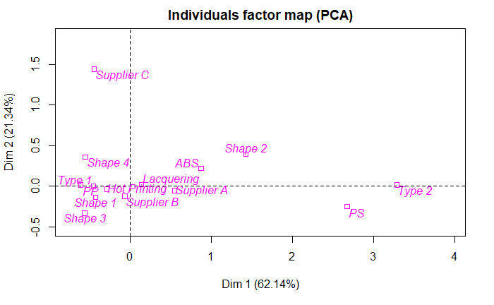

We can observe that Type2 and PS are quite high on the dim 1 axis. If we consider the correlation circle, it appears that the Type 2 and PS Caps would tend to be bigger dimension caps (weight, diameter and length), with a rather high price. However, they are very close to the dim 1 axis which shows that the number of pieces may not have an effect on the impereability and the raw material chosen for manufacturing a cap.

The cumulative percentage of inertia of dimension 1 and 2 is 83% and the independant variables inertia for the two first dimensions is 51.4% on average. We can deduce that the 2D vision of the dataset given by the PCA is quite accurate and that the variables are very correlated as they are well above the thershold of independant variables inertia. The correlation circle tends to confirm this as many of the variables seem to behave in an extremely similar manner.

## QUESTION 8

```r
print(eigen_v_cov_matrix<- eigen(cor(data_clean[,c(3,4,5,9,12)])))
```

```
eigen() decomposition
$values
[1] 3.1071215080 1.0669070766 0.7768681861 0.0488056018 0.0002976274

$vectors
           [,1]        [,2]       [,3]        [,4]         [,5]
[1,] -0.5588628  0.02465848 -0.1635220  0.40462804  0.704699279
[2,] -0.5545258  0.02776230 -0.1170916 -0.82340519  0.004877760
[3,]  0.1144314 -0.81582341 -0.5663548 -0.02402311  0.001670772
[4,]  0.2336274  0.57669494 -0.7823874 -0.02664140 -0.001152879
[5,] -0.5590145  0.02182469 -0.1632860  0.39622363 -0.709486443
```

```r
print(eigen_v_cov_matrix$vectors[,c(1,2)])
```

```
           [,1]        [,2]
[1,] -0.5588628  0.02465848
[2,] -0.5545258  0.02776230
[3,]  0.1144314 -0.81582341
[4,]  0.2336274  0.57669494
[5,] -0.5590145  0.02182469
```

The 2 most synthetic variables are the 2 eigenvectors linked to the 2 eigen values 3.107 and 1.07

## QUESTION 9

PCA is used as a pre-processing operation before clustering as the AHC and k-means are applied most of the time on the 3 first components of the PCA which gives a more precise idea of the centers of the data. In this data, considering the inertia of the eigenvalues, we would choose 3 components as the 3 first eigenvectors cumulate 99% of the inertia (above the 95% threshold.

Any additional component would not bring valuabe information, would make the model more complicated and could even give weight to data that may simply be “noise”

## QUESTION 10

This functions calculates the distance between the points of a cluster depending on the number of clusters used in the kmeans function. We can see that after the 4th cluster, there is no significant advantage of any additional cluster. We can also see that the gap between the third of fourth cluster is important.

The question is then whether to keep 3 or 4 clusters. Considering the wider improvement between the the 3rd and 4th cluster than between the 2nd and 4th, we choose to keep 4 clusters.

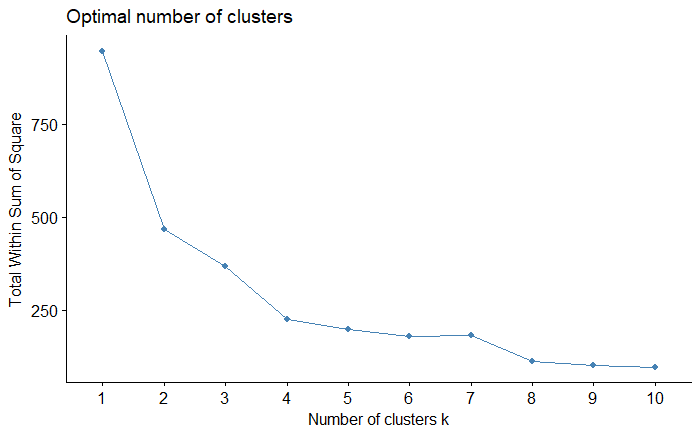

```r
data_kmeans <- res.pca$ind$coord[,1:3]
fviz_nbclust(data_kmeans, kmeans, method = "wss")
```

We can see with this that the in-between inertia is reduced by about 50% up to the third cluster. It slows down significatively when it reaches 4 clusters, which would indicate that 4 clusters would be the optimal division.

[figure not shown]

```r
res.kmeans <- kmeans(data_kmeans, 4, nstart = 20)
```

## QUESTION 11

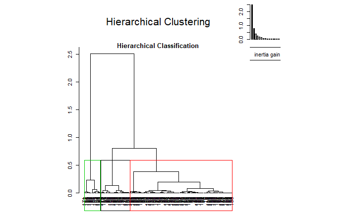

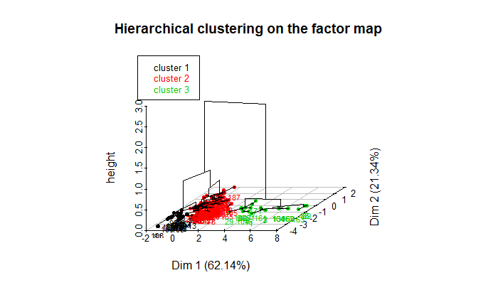

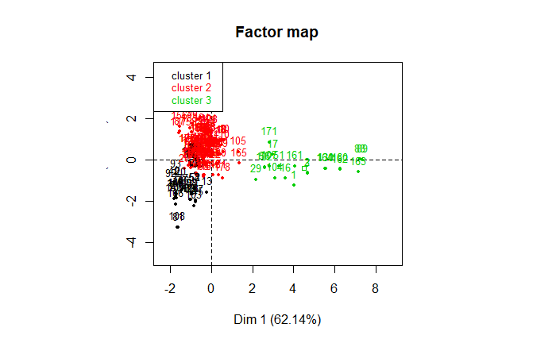

The HCA seems to show that the optimal number of clusters may be 3. In order to be able to compare both options, we display a new kmeans with 3 clusters below.

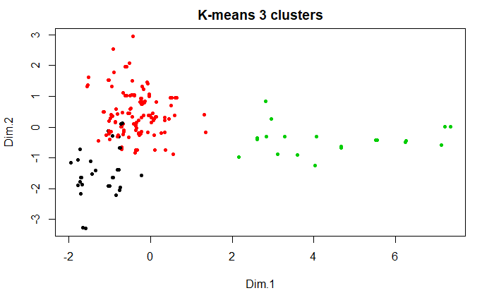

```r
res.kmeans <- kmeans(data_kmeans, 3, nstart = 20)
plot(data_kmeans, col = res.kmeans$cluster, pch = 20, main = "K-means 3 clusters")
```

## QUESTION 12

```r
res.hcpc$desc.var$quanti$`2`
```

```
                 v.test Mean in category Overall mean sd in category   Overall sd      p.value
nb.of.pieces   5.739229         4.503759     4.115183   1.352381e+00 1.413225e+00 9.510856e-09
Price         -2.999298        15.521715    16.552332   4.620374e+00 7.172431e+00 2.706026e-03
weight        -5.297059         1.416482     1.714121   3.882302e-01 1.172854e+00 1.176825e-07
Length        -5.533133         8.244766    10.329589   2.492726e+00 7.864783e+00 3.145605e-08
Diameter      -5.565997         1.032748     1.294639   3.121379e-01 9.821218e-01 2.606582e-08
Mature.Volume -8.031930     47177.255639 82206.026178   3.971314e+04 9.103190e+04 9.595124e-16
```

## QUESTION 13

The choice of 3 components is obvious with the PCA data as 3 components describe already 99% of the inertia and getting one more dimension would make the model more complicated for virtually 0 progress in terms of precision. As for the hypothesis of 2 components, it only gives a 83% of inertia, which is below the target 95%.

It can be verified by computing the AHC with 2 to 6 clusters, which shows very little change and add much complexity to the model without necessarily providing coherence for clusters (the 3rd and 4th clusters appear to be extremely close.

## QUESTION 14

```r
catdes(data_clean,num.var=2)
```

```
Chi-squared approximation may be incorrectChi-squared approximation may be incorrectChi-squared approximation may be incorrectChi-squared approximation may be incorrect
```

[output not shown]

This gives clear insight to the company on the specificity of each supplier and enables them to know which supplier may meet their needs for specific products.

For example, supplier A seems to be specialized in PS Raw Material whereas Supplier B specializes in ABS material. If the company orders a wide amount of caps, they may not have an exact idea of the specialties of each supplier. This would en able them to know better their business partners, and maximize thei influence. Indeed, if they decide they need a new cap in PS material, they may want to turn to supplier A and offer them exclusivity on PS material caps in exchange for the exclusivity. This wouldn’t hurt their supply chain, as supplier A is already supplying PS material caps.

This is a very powerful supply chain optimization tool.

## QUESTION 15

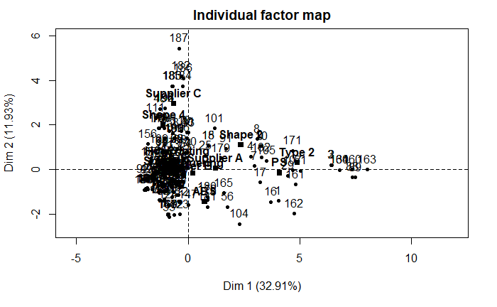

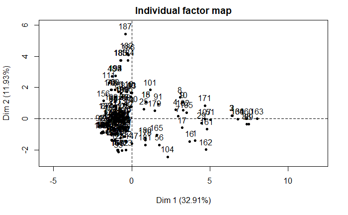

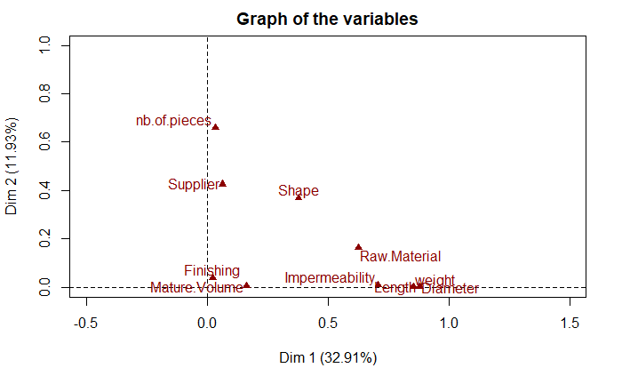

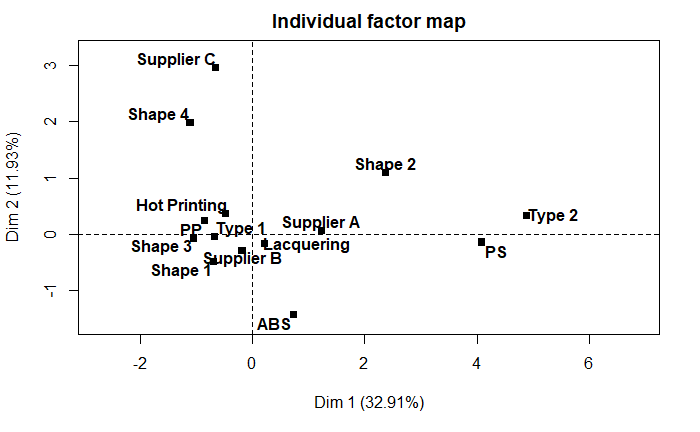

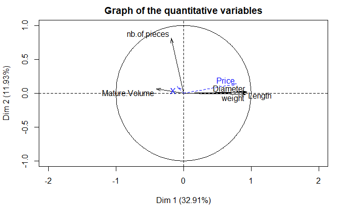

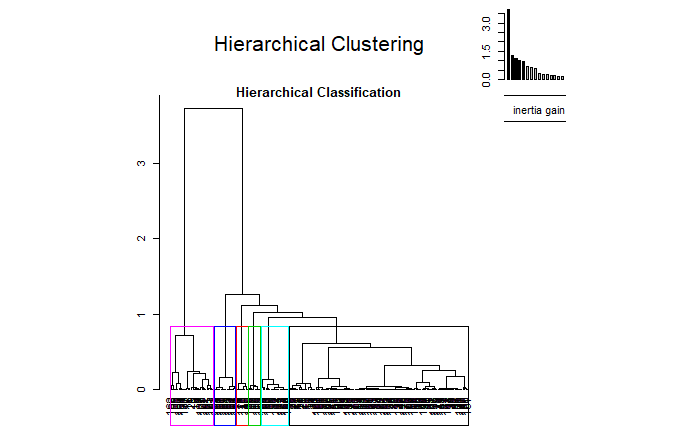

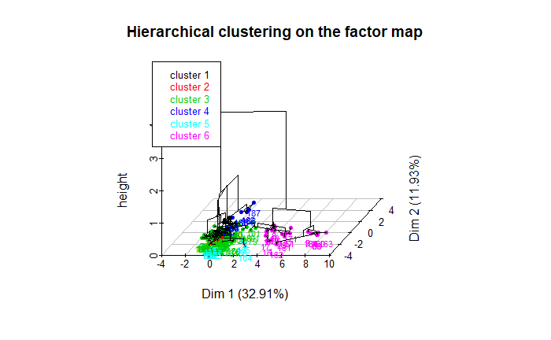

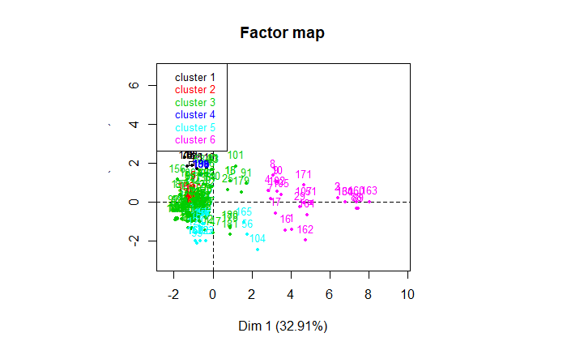

```r
res.hcpc <- HCPC(res.famd, nb.clust = -1)
```

```r
summary(res.famd, nbelements =  10, ncp = 6  )
```

```
Call:
FAMD(base = data_clean, ncp = 10, sup.var = c(1, 11))


Eigenvalues
                      Dim.1  Dim.2  Dim.3  Dim.4  Dim.5  Dim.6  Dim.7  Dim.8  Dim.9 Dim.10
Variance              4.607  1.670  1.468  1.277  1.002  0.894  0.771  0.677  0.605  0.457
% of var.            32.907 11.929 10.489  9.122  7.157  6.382  5.509  4.832  4.319  3.264
Cumulative % of var. 32.907 44.835 55.324 64.446 71.604 77.986 83.494 88.327 92.645 95.910

Individuals (the 10 first)
                   Dist    Dim.1    ctr   cos2    Dim.2    ctr   cos2    Dim.3    ctr   cos2    Dim.4    ctr   cos2
1              |  5.582 |  4.048  1.862  0.526 | -1.396  0.611  0.063 |  0.281  0.028  0.003 | -1.336  0.731  0.057 |
2              |  6.740 |  6.424  4.690  0.908 |  0.211  0.014  0.001 |  0.676  0.163  0.010 | -1.557  0.994  0.053 |
3              |  6.739 |  6.414  4.676  0.906 |  0.214  0.014  0.001 |  0.706  0.178  0.011 | -1.560  0.998  0.054 |
4              |  4.888 |  2.824  0.906  0.334 |  0.590  0.109  0.015 | -0.057  0.001  0.000 | -2.848  3.325  0.339 |
5              |  5.806 | -0.998  0.113  0.030 |  0.793  0.197  0.019 |  2.790  2.776  0.231 | -1.322  0.716  0.052 |
6              |  3.467 | -0.041  0.000  0.000 |  1.417  0.630  0.167 |  0.732  0.191  0.045 | -1.404  0.808  0.164 |
7              |  4.922 |  2.980  1.009  0.367 |  0.161  0.008  0.001 |  0.140  0.007  0.001 | -2.931  3.523  0.355 |
8              |  5.087 |  3.107  1.097  0.373 |  1.372  0.590  0.073 |  0.898  0.288  0.031 | -2.072  1.760  0.166 |
9              |  4.928 |  3.273  1.217  0.441 |  1.050  0.346  0.045 | -0.129  0.006  0.001 | -2.522  2.608  0.262 |
10             |  4.931 |  3.292  1.232  0.446 |  1.051  0.346  0.045 | -0.127  0.006  0.001 | -2.515  2.592  0.260 |
                Dim.5    ctr   cos2    Dim.6    ctr   cos2
1              -0.623  0.203  0.012 |  0.060  0.002  0.000 |
2              -0.390  0.079  0.003 | -0.111  0.007  0.000 |
3              -0.406  0.086  0.004 | -0.078  0.004  0.000 |
4              -0.270  0.038  0.003 | -1.561  1.427  0.102 |
5               3.899  7.942  0.451 | -0.396  0.092  0.005 |
6               0.355  0.066  0.010 | -2.030  2.416  0.343 |
7              -0.351  0.064  0.005 | -1.350  1.068  0.075 |
8               0.181  0.017  0.001 | -2.392  3.352  0.221 |
9              -0.252  0.033  0.003 | -1.476  1.277  0.090 |
10             -0.253  0.033  0.003 | -1.470  1.266  0.089 |

Continuous variables
                  Dim.1    ctr   cos2    Dim.2    ctr   cos2    Dim.3    ctr   cos2    Dim.4    ctr   cos2    Dim.5
Diameter       |  0.938 19.100  0.880 |  0.016  0.016  0.000 |  0.045  0.140  0.002 |  0.194  2.952  0.038 | -0.011
weight         |  0.924 18.516  0.853 | -0.020  0.024  0.000 |  0.066  0.296  0.004 |  0.194  2.936  0.038 |  0.044
nb.of.pieces   | -0.184  0.734  0.034 |  0.812 39.471  0.659 | -0.256  4.479  0.066 |  0.195  2.991  0.038 |  0.057
Mature.Volume  | -0.405  3.557  0.164 |  0.065  0.253  0.004 |  0.549 20.490  0.301 | -0.068  0.365  0.005 | -0.252
```

[output cut: 21 more lines]

```
Shape 4        |  -1.105   0.241   0.046  -1.484 |   1.983   5.907   0.148   4.423 |   2.440  11.562   0.225   5.802 |
Type 1         |  -0.668   1.852   0.954 -11.602 |  -0.045   0.062   0.004  -1.283 |  -0.052   0.111   0.006  -1.602 |
Type 2         |   4.883  13.527   0.954  11.602 |   0.325   0.456   0.004   1.283 |   0.381   0.809   0.006   1.602 |
Hot Printing   |  -0.474   0.344   0.092  -2.112 |   0.364   1.538   0.054   2.688 |   1.019  15.647   0.424   8.040 |
                 Dim.4     ctr    cos2  v.test     Dim.5     ctr    cos2  v.test     Dim.6     ctr    cos2  v.test
Supplier A      -1.811  30.543   0.472  -9.348 |  -0.062   0.058   0.001  -0.360 |  -1.110  23.439   0.177  -6.849 |
Supplier B       0.367   6.408   0.381   8.310 |  -0.020   0.031   0.001  -0.509 |   0.123   1.460   0.042   3.318 |
Supplier C      -0.130   0.076   0.001  -0.447 |   0.339   0.838   0.007   1.312 |   1.003   9.236   0.062   4.113 |
Shape 1         -0.035   0.050   0.001  -0.619 |  -0.151   1.538   0.025  -3.028 |   0.033   0.094   0.001   0.708 |
Shape 2         -0.299   1.294   0.012  -2.027 |   0.074   0.130   0.001   0.569 |  -0.057   0.097   0.000  -0.464 |
Shape 3         -0.113   0.033   0.001  -0.289 |   4.013  67.198   0.663  11.555 |   0.704   2.600   0.020   2.147 |
Shape 4          2.362  14.330   0.211   6.024 |  -1.984  16.425   0.149  -5.713 |  -0.922   4.463   0.032  -2.812 |
Type 1           0.056   0.166   0.007   1.830 |   0.011   0.012   0.000   0.428 |   0.004   0.001   0.000   0.143 |
Type 2          -0.405   1.213   0.007  -1.830 |  -0.084   0.084   0.000  -0.428 |  -0.027   0.011   0.000  -0.143 |
Hot Printing     0.393   3.071   0.063   3.322 |   0.293   2.770   0.035   2.794 |  -0.550  12.297   0.123  -5.560 |
```

This shows that adding variables and dimensions makes it way more difficult to obtain a clustering and significatively reduces the precision of the analysis compared to the above PCA. We observe that 10 dimensions are now neeed to reach the 95% inertia thershold and that no other significant correlation has appeared on the correlation circle.

The impact of this analysis is to make the clustering way more difficult as 6 clusters are now needed to obtain optimal results. We are faced with a “chain” type tree with numerous branches on the main right branch which doesn’t seem to add any information but makes the tree way more difficult to read.

We do not obtain much more information as the categorical data map is quite similar to the one obtained with PCA on quantitative var and quali.sup mapping.

## QUESTION 16

```r
lm(Price ~ Supplier + Diameter + weight + nb.of.pieces + Shape + Impermeability + Finishing + Mature.Volume + Raw.Material + Price + Length, data_clean)
```

[output not shown]

```
Call:
lm(formula = Price ~ Supplier + Diameter + weight + nb.of.pieces +
    Shape + Impermeability + Finishing + Mature.Volume + Raw.Material +
    Price + Length, data = data_clean)

Coefficients:
         (Intercept)    SupplierSupplier B    SupplierSupplier C              Diameter                weight
           9.336e+00            -6.578e-01            -2.357e+00             7.230e+00             9.984e-01
        nb.of.pieces          ShapeShape 2          ShapeShape 3          ShapeShape 4  ImpermeabilityType 2
           8.644e-01            -3.490e-01             1.742e+00             5.608e+00             5.774e+00
 FinishingLacquering         Mature.Volume        Raw.MaterialPP        Raw.MaterialPS                Length
          -5.928e-01            -7.291e-06            -2.051e+00            -3.144e+00            -4.527e-01
```

With this regression we can calculate the price by multiplying the coefficient to the corresponding observations and adding the intercept. For the categorical variables the coefficent is multiplied by “1” if the observation belongs to the category and 0 otherwise.

## QUESTION 18

The idea to put 0 or the median would destroy the model as adding a 0 would totally change the means of every variable, destroy the structure of the variance and thus affect the correlation between the variables. The median idea is as bad as it would drastically reduce the variance of every variable and change every results for PCA and clustering analysis, as the inertia is the main criteria for these analysis.

Creating a “missing” category would have 2 outcomes : either you remove the rows with “missing” in it, which will cause a loss of information, or you don’t and the impact would just be adding one irrelevant qualitative variable to the model, while the “missing” will act exactly as the previous “NA”